# Extra Credit Lab - More on`ggplot`

$~$

## Lab

This lab is optional and will be rewarded with a small amount of extra credit. You may work on it with up to one partner and turn in a single copy with both of your names on it.

We’ll continue using the two data sets introduced in our previous lab, as well as the `ggplot2` package:

```r
library(ggplot2) # You should already have this installed

## College majors
college_majors = read.csv("https://remiller1450.github.io/data/majors.csv")

## Police involved deaths
police = read.csv("https://remiller1450.github.io/data/Police.csv")
```

### Themes and labels

The graphics you made in our previous lab are informative, but not polished enough to be used in any sort of formal capacity. This lab will cover a few ways to make your graphics more professional and polished.

The `ggplot2` package comes with several pre-built themes that can be used to change the appearance of a graph, these include:

- `theme_bw()`
- `theme_linedraw()`
- `theme_light()` and `theme_dark()`
- `theme_minimal()`
- `theme_classic()`
- `theme_void()`

These functions can be added using layering to change the theme, the example below displays a scatter plot using `theme_bw()`:

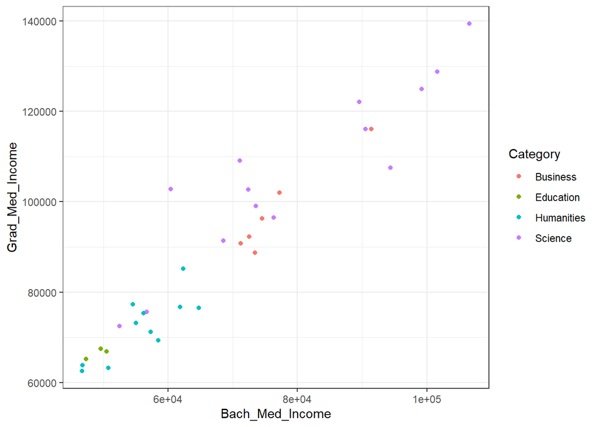

```r
ggplot(data = college_majors, mapping = aes(x = Bach_Med_Income, y = Grad_Med_Income, color = Category)) +
  geom_point() +
  theme_bw()
```

Next, you might notice that the x-axis and y-axis are labeled using the variable names we specified in `aes()`, including the unprofessional looking underscores. We can provide a different label for any aesthetic present in our graph using the `labs()` function. This is demonstrated below:

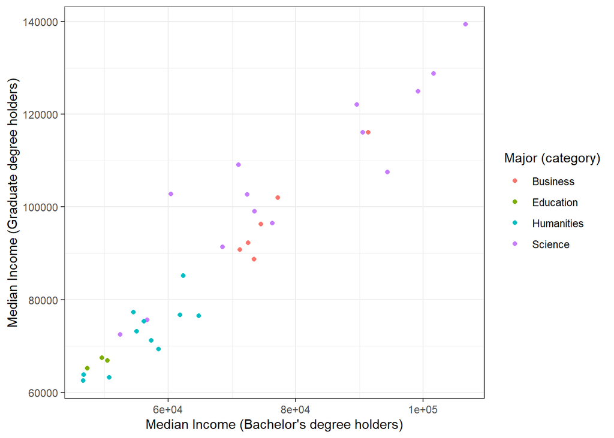

```r
ggplot(data = college_majors, mapping = aes(x = Bach_Med_Income, y = Grad_Med_Income, color = Category)) +
  geom_point() +
  theme_bw() +
  labs(x = "Median Income (Bachelor's degree holders)",
       y = "Median Income (Graduate degree holders)",
       color = "Major (category)")
```

**Question #1**: Using the `police` data, create a clustered bar chart displaying the variables `manner_of_death` and `threat_level`. Change the theme of the plot to `theme_minimal()` and use `labs()` to change the labels of these variables to no longer show the underscores.

$~$

### Scales and transformations

Sometimes relationships between variables might be difficult to see due to the presence of skew and/or outliers. As and example, consider the following visualization:

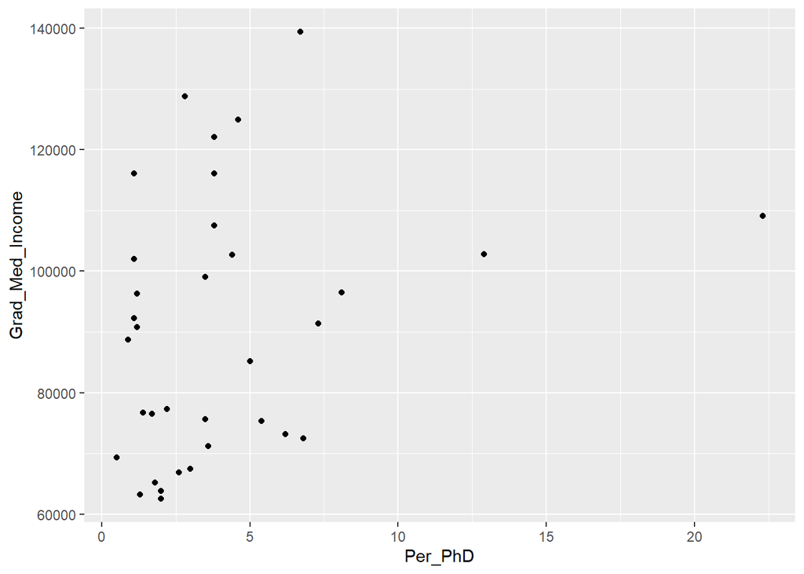

```r
ggplot(data = college_majors, mapping = aes(x = Per_PhD, y = Grad_Med_Income)) +
  geom_point()
```

The one major with $> 20\%$ of its workforce holding a PhD makes it difficult to see if there’s any relationship present among the more typical majors where $< 10\%$ of the workforce holds a PhD.

Without changing the underlying data at all, we can change the x-axis scale used to display the data via `scale_x_continuous()` and the `trans` (short for transformation) argument:

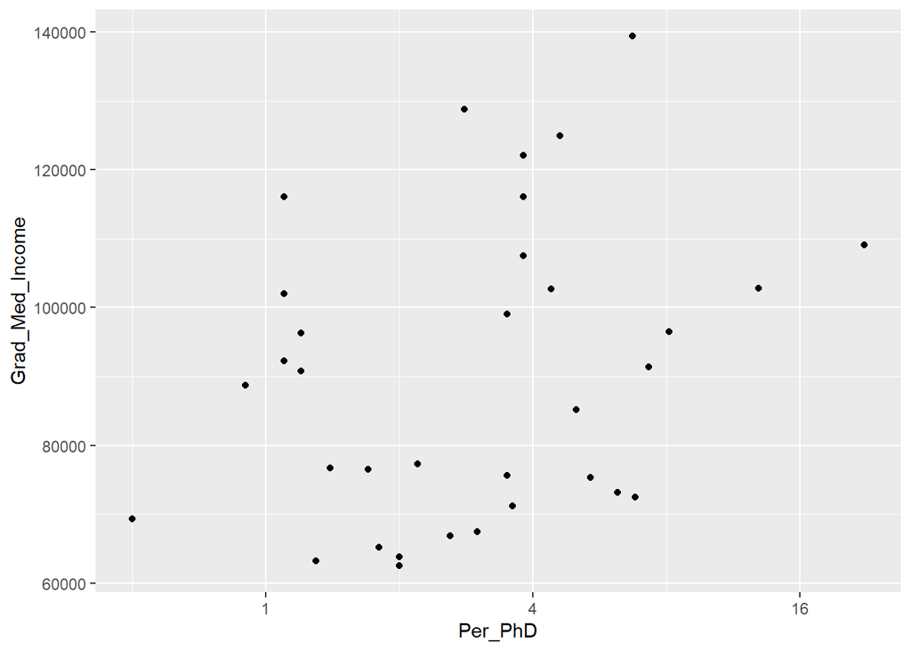

```r
ggplot(data = college_majors, mapping = aes(x = Per_PhD, y = Grad_Med_Income)) +
  geom_point() +
  scale_x_continuous(trans = "log2")
```

Each 1-unit increment on the log2 scale reflects a doubling on the original scale. So, we might conclude there is a weak, non-linear relationship between these two variables on the original scale, or a weak, linear relationship on the log2 scale.

Note that there are a wide variety of layer functions that use the general format `scale_AESTHETIC_TYPE()`. A few examples are listed below:

- `scale_y_continuous()` - can re-scale a continuous variable used in the `y` aesthetic
- `scale_color_continuous()` - can change the color scale of a continuous variable to a different pre-built color pallet
- `scale_color_gradient()` - can create a custom gradient scale for a continuous variable
- `scale_fill_brewer()` - can change the colors used to fill the bars of a bar chart

**Question #2**: Starting with the graph you created in Question 1, add another layer that changes the fill colors to the palette “Set3”. If you’re curious you can find a nice diagram showing all of the pre-loaded color palettes about 1/3 of the way down the page at [this link](https://www.datanovia.com/en/blog/top-r-color-palettes-to-know-for-great-data-visualization/) .

$~$

### Category reordering

When using a categorical variable in a graph the default behavior of `ggplot` is to arrange the categories in alphabetical order. However, many graphics tend to be more information when groups are arranged in ascending/descending order.

The `reorder()` function can be used inside of `aes()` to reorder the categories of a variable. The code below provides an example:

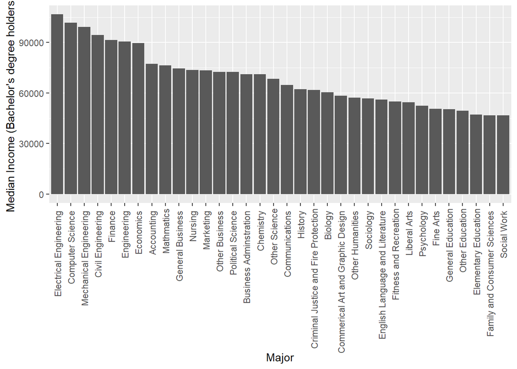

```r
ggplot(data = college_majors, aes(x = reorder(Major, X = Bach_Med_Income, decreasing = TRUE), y = Bach_Med_Income)) +
  geom_col() +
  scale_x_discrete(guide = guide_axis(angle = 90)) +
  labs(x = "Major", y = "Median Income (Bachelor's degree holders)")
```

A couple of things to notice with this example:

1. The argument `X = Bach_Med_Income` inside of `reorder()` told the function to reorder the categories of `Major` according to the values of `Bach_Med_Income`.
2. The argument `decreasing = TRUE` arranged the categories in descending order of median bachelor’s degree income.

The `reorder()` function also allows to reorder a categorical variable according to a function of another variable. This is useful for order boxplots or dot plots, as demonstrated below:

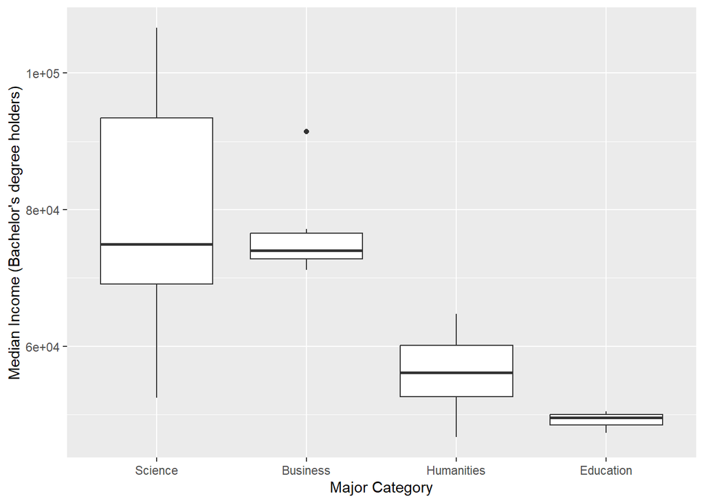

```r
ggplot(data = college_majors, aes(x = reorder(Category, X = Bach_Med_Income, FUN = median, decreasing = TRUE), y = Bach_Med_Income)) +
  geom_boxplot() +
  labs(x = "Major Category", y = "Median Income (Bachelor's degree holders)")
```

Here we arrange `Category` in descending order according to the median value of `Bach_Med_Income`. The argument `FUN = median` tells reorder to use the `median()` function to guide the reordering.

These examples both use a variable in the data to guide the reordering, but this is a problem for us when we’d like to use `geom_bar()`, which calculates the height of the bars internally. Unfortunately, there’s no easy way to handle this using `reorder()`, but we can use the `fct_infreq()` function in the `forcats` package:

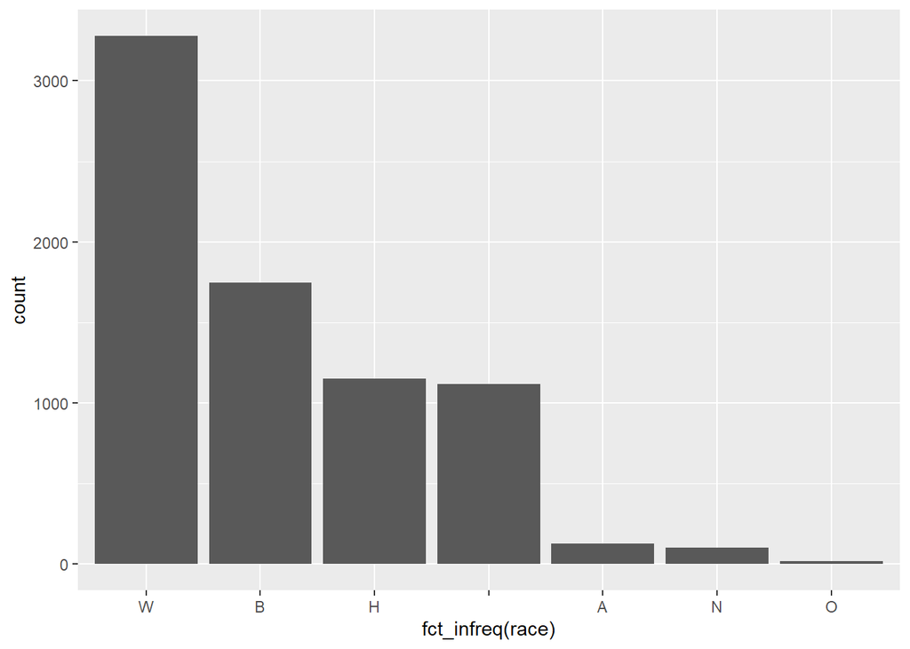

```r
# install.packages("forcats")
library(forcats)

ggplot(data = police, aes(x = fct_infreq(race))) + geom_bar()
```

In summary:

- We can use `reorder()` to change the ordering of a categorical variable according to either:
  - Another variable in our data, using the argument `X = var_name`
  - A *function* of another variable in our data, using the arguments `X = var_name` and `FUN = function_name`
- We can use `fct_infreq()` to change the ordering of categories in bar charts that rely upon `ggplot()` to calculate the heights of the bars internally.

**Question #3**: Using the `college_majors` data, create a column chart that shows the percentage of females in the workforce for each major in ascending (increasing) order.

**Question #4**: Using the `police` data, create bar chart that shows the frequency of police involved deaths by state with the states arranged in descending (decreasing) order.

**Question #5**: Using the `police` data, create a set of side-by-side box plots that show the distribution of ages among those involved in police involved deaths by race/ethnicity, where the racial/ethnic categories appear along the x-axis ordered by their corresponding mean age.